## Proyecto (parte2): Tasa de conclusión, primaria, grupo de edades 12-13 (% del total)

## Introducción

# Tabla de contenido - Proyecto (parte2)

1. Histogramas
2. Gráfica de barras
3. Gráfica de mapas

## Histograma

Un histograma es una forma de representar la distribución de *frecuencia* del conjunto de datos numéricos. La forma en que funciona es que divide el eje x en *contenedores*, asigna cada punto de datos en nuestro conjunto de datos a un contenedor y luego cuenta el número de puntos de datos que se han asignado a cada contenedor. Entonces, el eje y es la frecuencia o el número de puntos de datos en cada bin. Tenga en cuenta que podemos cambiar el tamaño del contenedor y, por lo general, es necesario ajustarlo para que la distribución se muestre bien.

**Pregunta:** ¿Cuál es la distribución de frecuencia del número (población) que concluyeron primaria en el año 2013?

Antes de continuar con la creación del diagrama de histograma, examinemos primero los datos divididos en intervalos. Para hacer esto, usaremos el método `histogram` de **Numpy** para obtener los rangos de bin y los conteos de frecuencia de la siguiente manera:

```python
# veamos rápidamente los datos de 2013
df_tendencia['2013'].head()
```

```
REGION
Amazonas    71.296644
Ancash      75.246196
Apurímac    79.448232
Arequipa    89.820127
Ayacucho    72.782221
Name: 2013, dtype: float64
```

```python
# np.histogram returns 2 values
count, bin_edges = np.histogram(df_tendencia['2013'])

print(count) # frequency count
print(bin_edges) # bin ranges, default = 10 bins (10 rangos de agrupamiento)
```

```
[2 0 0 5 2 4 2 5 3 3]
[59.84066679 63.28819655 66.73572631 70.18325607 73.63078583 77.07831559
 80.52584535 83.97337511 87.42090487 90.86843463 94.31596439]
```

- Bin 1: Rango (59.84 a 63.28) se encuentran 2 Departamentos
- Bin 2: Rango (63.28 a 66.73) se encuentran 0 Departamentos. Así sucesivamente...
- Bin 10: Rango (90.87 a 94.32) se encuentran 3 Departamentos.

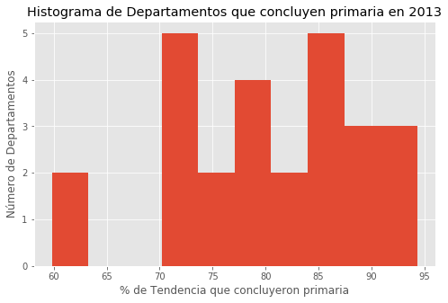

```python
df_tendencia['2013'].plot(kind='hist', figsize=(8, 5))

plt.title('Histograma de Departamentos que concluyen primaria en 2013') # add a title to the histogram
plt.ylabel('Número de Departamentos') # add y-label
plt.xlabel('% de Tendencia que concluyeron primaria') # add x-label

plt.show()
```

También podemos trazar varios histogramas en el mismo diagrama. Por ejemplo, tratemos de responder las siguientes preguntas usando un histograma.

**Pregunta**: ¿Cuál es la distribución en las Regiones:Lima Metropolitana, Arequipa y Piura para los años 2001 - 2015?

```python
# Permite ver rápidamente el dataset
df_tendencia.loc[['Lima Metropolitana', 'Arequipa', 'Piura'], años]
```

| REGION | 2001 | 2002 | 2003 | 2004 | 2005 | 2006 | 2007 | 2008 | 2009 | 2010 | 2011 | 2012 | 2013 | 2014 | 2015 |
| --- | --- | --- | --- | --- | --- | --- | --- | --- | --- | --- | --- | --- | --- | --- | --- |
| Lima Metropolitana | 81.765596 | 80.247977 | 85.7696 | 80.860804 | 82.199969 | 82.563505 | 84.950125 | 84.261933 | 86.509562 | 86.746238 | 87.602888 | 88.552365 | 87.683754 | 89.320336 | 91.006083 |
| Arequipa | 80.425588 | 82.699463 | 74.577 | 89.332278 | 86.075536 | 81.631867 | 88.978596 | 90.419176 | 87.895861 | 93.502294 | 86.709338 | 90.422880 | 89.820127 | 89.085301 | 92.104252 |
| Piura | 69.998682 | 66.784040 | 67.6793 | 77.220608 | 74.714148 | 69.987455 | 77.544082 | 68.999683 | 76.207409 | 78.329764 | 84.031454 | 78.237481 | 77.264886 | 82.076339 | 76.808891 |

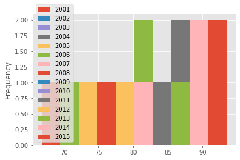

```python
# generando el histograma
df_tendencia.loc[['Lima Metropolitana', 'Arequipa', 'Piura'], años].plot.hist()
```

Eso no se ve bien!

No se preocupe, a menudo se encontrará con situaciones como esta al crear tramas. La solución a menudo radica en cómo se estructura el conjunto de datos subyacente.

En lugar de trazar la distribución de frecuencia de la población de las 3 Regiones, *pandas* trazó la distribución de frecuencia de la población para los "años".

Esto se puede solucionar fácilmente transponiendo primero el conjunto de datos y luego trazando como se muestra a continuación.

```python
# transpose dataframe
df_t = df_tendencia.loc[['Lima Metropolitana', 'Arequipa', 'Piura'], años].transpose()
df_t.head(15)
```

| REGION | Lima Metropolitana | Arequipa | Piura |
| --- | --- | --- | --- |
| 2001 | 81.7656 | 80.4256 | 69.9987 |
| 2002 | 80.248 | 82.6995 | 66.784 |
| 2003 | 85.7696 | 74.577 | 67.6793 |
| 2004 | 80.8608 | 89.3323 | 77.2206 |
| 2005 | 82.2 | 86.0755 | 74.7141 |
| 2006 | 82.5635 | 81.6319 | 69.9875 |
| 2007 | 84.9501 | 88.9786 | 77.5441 |
| 2008 | 84.2619 | 90.4192 | 68.9997 |
| 2009 | 86.5096 | 87.8959 | 76.2074 |
| 2010 | 86.7462 | 93.5023 | 78.3298 |
| 2011 | 87.6029 | 86.7093 | 84.0315 |
| 2012 | 88.5524 | 90.4229 | 78.2375 |
| 2013 | 87.6838 | 89.8201 | 77.2649 |
| 2014 | 89.3203 | 89.0853 | 82.0763 |
| 2015 | 91.0061 | 92.1043 | 76.8089 |

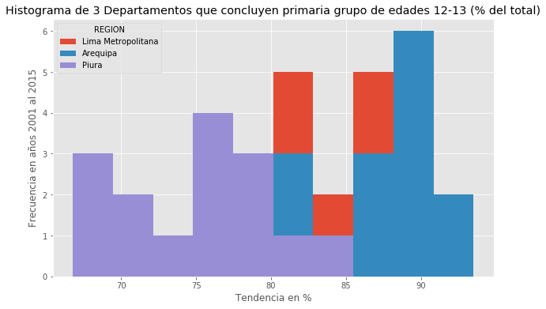

```python
# generando el histograma
df_t.plot(kind='hist', figsize=(10, 6))

plt.title('Histograma de 3 Departamentos que concluyen primaria grupo de edades 12-13 (% del total)')
plt.ylabel('Frecuencia en años 2001 al 2015')
plt.xlabel('Tendencia en %')

plt.show()
```

## Gráfica de Barras

**Gráfica de Barras (Dataframe)**

Un diagrama de barras es una forma de representar datos donde la *longitud* de las barras representa la magnitud / tamaño de la característica / variable. Los gráficos de barras generalmente representan variables numéricas y categóricas agrupadas en intervalos.

Para crear un diagrama de barras, podemos pasar uno de dos argumentos a través del parámetro `kind` en`plot ()`:

*`kind = bar` crea un diagrama de barra* vertical`kind = barh` crea un diagrama de barras *horizontal*

**Diagrama de barra vertical**

En los gráficos de barras verticales, el eje x se usa para etiquetar, y la longitud de las barras en el eje y corresponde a la magnitud de la variable que se mide. Los gráficos de barras verticales son particularmente útiles para analizar datos de series temporales. Una desventaja es que carecen de espacio para el etiquetado de texto al pie de cada barra.

**Comencemos analizando regiones en forma individual:**

Tomemos como ejemplo a la Región de Arequipa.

```python
# paso 1: conseguir los datos
df_arequipa = df_tendencia.loc['Arequipa', años]
df_arequipa.head()
```

```
2001    80.4256
2002    82.6995
2003     74.577
2004    89.3323
2005    86.0755
Name: Arequipa, dtype: object
```

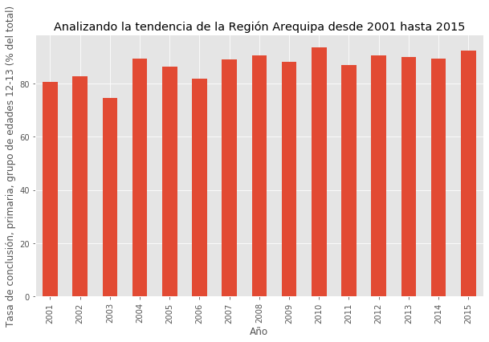

```python
# step 2: ploteo de los datos
df_arequipa.plot(kind='bar', figsize=(10, 6))

plt.xlabel('Año') # add to x-label to the plot
plt.ylabel('Tasa de conclusión, primaria, grupo de edades 12-13 (% del total)') # add y-label to the plot
plt.title('Analizando la tendencia de la Región Arequipa desde 2001 hasta 2015') # add title to the plot

plt.show()
```

**Ploteo de barra horizontal**

A veces es más práctico representar los datos horizontalmente, especialmente si necesita más espacio para etiquetar las barras. En los gráficos de barras horizontales, el eje 'y' se usa para etiquetar, y la longitud de las barras en el eje 'x' corresponde a la magnitud de la variable que se mide. Como verá, hay más espacio en el eje 'y' para etiquetar las variables categetoricas.

**Pregunta:** Utilizando el generador de secuencias de comandos y el conjunto de datos `df_tendencia`, cree un diagrama de barras *horizontal* que muestre el *promedio* de las tendencias año a año, para el período 2001-2015. Etiquete cada región con su valor correspondiente.

Paso 1: Obtenga los datos correspondientes de todas las 25 regiones. (26 considerando Las 2 Lima)

```python
# La suma de las filas: df_tendencia.sum(axis=1)
# df_tendencia.sum(axis=1) / (len(df_tendencia.columns)-1)   ## -1 para restar la columna Region

df_tendencia['Promedio'] = df_tendencia.sum(axis=1) / (len(df_tendencia.columns)-1)

# sort dataframe on 'Total' column (descending)
df_tendencia.sort_values(by='Promedio', ascending=True, inplace=True)

# get top de todas las regiones
df_top25 = df_tendencia['Promedio'].tail(26)
df_top25
```

```
REGION
Huánuco               52.850091
Loreto                55.559909
Huancavelica          59.989752
Ayacucho              62.625704
Amazonas              63.912398
Cajamarca             65.406597
Ucayali               67.226292
San Martín            70.170485
Ancash                70.317388
Cusco                 70.678730
La Libertad           71.002074
Apurímac              72.574852
Pasco                 75.447277
Piura                 75.586066
Lambayeque            77.270117
Junín                 77.614633
Lima Provincias       79.819399
Puno                  80.319762
Tumbes                81.904652
Madre de Dios         82.224939
Callao                82.308071
Ica                   84.746891
Lima Metropolitana    85.305081
Moquegua              86.382008
Tacna                 86.477551
Arequipa              87.793040
Name: Promedio, dtype: float64
```

Paso 2: Datos de ploteo:

- Use `kind = 'barh'` para generar un gráfico de barras con barras horizontales.
- Asegúrese de elegir un buen tamaño para la trama y etiquetar sus ejes y darle un título a la trama de ploteo.
- Recorre las regiones y anota el %promedio usando la función de anotate de la interfaz de scripting.

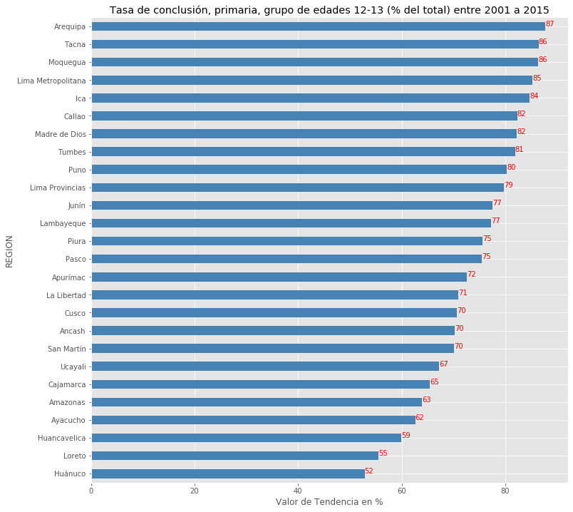

```python
# generando el ploteo
df_top25.plot(kind='barh', figsize=(12, 12), color='steelblue')
plt.xlabel('Valor de Tendencia en %')
plt.title('Tasa de conclusión, primaria, grupo de edades 12-13 (% del total) entre 2001 a 2015')

# anota valor de etiqueta para cada país
for index, value in enumerate(df_top25):
    label = format(int(value), ',') # format int with commas

    # coloque el texto al final de la barra
    plt.annotate(label, xy=(value, index), color='red')

plt.show()
```

## Gráfica de Mapas

```python
import numpy as np  # utilizado para múltiples cómputos científicas en Python
import pandas as pd # librería para estructura de datos
import folium       # utilizada para grafica de mapas

# Define el mapa mundial centrado alrededor de Lima, Perú con un zoom bajo
# https://python-graph-gallery.com/288-map-background-with-folium/

world_map = folium.Map(location=[-12.0431800, -77.0282400], zoom_start=6, tiles='Stamen Terrain')
#Geolocalización de las primeras 5 ciudades según última gráfica
#https://www.antipodas.net/coordenadaspais/peru/lima.php
folium.Marker([-16.3988900, -71.5350000], popup='Arequipa').add_to(world_map)
folium.Marker([-18.0146500, -70.2536200], popup='Tacna').add_to(world_map)
folium.Marker([-17.1983200, -70.9356700], popup='Moquegua').add_to(world_map)
folium.Marker([-12.0431800, -77.0282400], popup='Lima Metropolitana').add_to(world_map)
folium.Marker([-14.0677700, -75.7286100], popup='Ica').add_to(world_map)
# mostrando el mapa
world_map
```

[interactive chart not shown]

Esta notebook en Jupiter ha tomada fuente de información de:

- Desarrollado por Lic.Daniel Zúñiga
- Referenciado del curso **edX** llamado [*Visualizing Data with Python*](http://cocl.us/DV0101EN_edX_LAB1).
- El excel trabajado ha sido descargado de: [*ESCALE (Estadística de Calidad Educativa)*](http://escale.minedu.gob.pe/indicadores)